# Introduction to dplyr

Jelany Duali

2023-06-01

### Overview

dplyr is package aimed at facilitating data manipulation. Basically, it helps you address the issue “my data is X and I want to transform it into Y”.

dplyr is largely oriented towards the manipulation of **dataframes**: two dimensional table of rows and columns.

Some of the important functions in this package:

- **mutate()** create a new variable (column) in your dataframe by modifying existing variables
- **select()** pick variables based on their names.
- **filter()** pick cases based on their values
- **summarise()** reduce multiple values down to a single summary
- **arrange()** change how rows are ordered in a dataframe

These functions can interact with the **group_by()** function, which allows us to apply them to different subgroups in our dataset.

First things first, we’ll install and load *dplyr*. You could also install the whole *tidyverse* package, which is actually suite of packages that includes *dplyr*.

In the next block of code, you can uncomment the first line to install dplyr.

```r
#install.packages("dplyr")
library(dplyr)
```

We’re also going to install and load the package *mefa4*, but that’s just because I want to use their abmibirds dataset for some examples. We’ll also be using the mtcars and iris dataset, from the *datasets* package, and starwars dataset, from *dplyr*.

- **abmibirds** is a dataset of bird point counts collected by the Alberta Biodiversity Monitoring Institute.
- **mtcars** is a dataset from the 1974 *Motor trends* US Magazine with the fuel consumption and 10 aspects of automobile design and performance for 32 automobiles
- **iris** gives the measurements in centimeters of the variables sepal length and width and petal length and width, respectively, for 50 flowers from each of 3 species of iris.
- **starwars** is a dataset with information on Star Wars characters. Note that it is a tibble instead of a dataframe. We’ll see what that is a bit later.

In the next block of code, you can uncomment the first line to install mefa4.

```r
#install.packages("mefa4")
library(mefa4)

# We can have a look at the first few lines of each dataset
head(abmibirds)
head(mtcars)
head(iris)
head(starwars)
```

### The pipe operator

Before we start going through examples for each function, we have to learn about the “pipe” operator: %>%

This operator allows you to take the result of one function call and feed it into another function. This way, you don’t have to call your results inside of the other function. Rstudio has shortcuts for typing the pipe operator: Ctrl + Shift + M (in Windows) and Cmd + Shift + M (on Mac).

Here are some examples with mtcars:

```r
# Subset the mtcars dataset to get only cars with 6 cylinders - without pipes
filter(mtcars, mtcars$cyl == 6)

# Subset the mtcars dataset to get only cars with 6 cylinders - with pipes
mtcars %>% filter(cyl == 6)

# For a more complex example, we can find the mean fuel consumption (mpg) of car models with different numbers of cylinders
mtcars %>%
   group_by(cyl) %>% # group by the number of cylinder
   summarise(mpg = mean(mpg)) # calculate the mean of each group

# The code printed the results, but we also can store them in a variable
mpg.by.cyl <- mtcars %>%
  group_by(cyl) %>%
  summarise(mpg = mean(mpg))

#Let's check the class of this object
class(mpg.by.cyl)
```

I’ll be using the pipe operator a lot in my examples for dplyr functions. But these functions can also be applied using the “conventional” approach of calling your data as a parameter.

### Tibbles

The code above returns a tibble, referred to as a “tbl_df” in R. Tibbles are similar to dataframes, with some tweaks. For example, they only print the first 10 columns when you enter them into your console.

You can read about the differences between dataframes and tibbles here: https://cran.r-project.org/web/packages/tibble/vignettes/tibble.html

Generally you can turn a tibble into a dataframe using **as.data.frame()**, and a dataframe into a tibble using **as_tibble()**.

We will use both tibbles and dataframes here.

```r
mpg.by.cyl <- as.data.frame(mpg.by.cyl) # convert to a dataframe
mpg.by.cyl <- as_tibble(mpg.by.cyl) # convert back to a tibble
```

### mutate

I think this is the most useful function in dplyr.

The mutate function allows you to create new columns that are functions of existing variables. It can also modify columns (if the name is the same as an existing column) and delete columns (by setting their value to NULL).

For example, the iris dataset has petal length and petal width. What if we wanted to use those measurements to estimate petal area?

```r
# Create a new dataframe with the petal area
iris %>%  mutate(Petal.Area = Petal.Length * Petal.Width)

# We could also have done this in base R (note: running this line modifies the iris dataset)
iris$Petal.Area <- iris$Petal.Length * iris$Petal.Width

# Delete the Petal.length column
iris %>%  mutate(Petal.Length = NULL)

# multiply values in the Petal.Length column by 100
iris %>%  mutate(Petal.Length = Petal.Length * 100)
```

Pretty straightforward. But what if we want to make a different operation depending on the row that we are in?

Let’s now look at the starwars dataset. It has the height of the different characters in cm. We’ll classify these characters as “tall” or “short” based on whether they are larger than 175 cm.

We can use the **if_else()** function to let the **mutate()** know whether a character in a row has a height that is greater than 175 cm. The height of each character is provided in the “height” column of the tibble.

Note that **if_else()** is distinct from the **ifelse()** function in base R because it can handle missing values with the “missing” argument.

```r
# Create a new tibble with a height class variable
sw.heights <- starwars %>%  mutate(height_class = if_else(height > 175,  # is the height greater than 175cm ?
                                      "tall", # if yes
                                      "short", # if no
                                      missing = "unknown",), .before = height) # if there is no value

# We can have a look at the relevevant columns of the tibble
sw.heights[, c("name", "height", "height_class")]
```

This would be a bit tricky to perform without dplyr. One way to do it would be with a loop, but that would be much less computationally efficient with a large database. Functions like mutate that operate on all elements of a vector at the same time are referred to as “vectorized” functions. They can often be used for the same purposes as loops.

If we want to perform more than two operations, we can use **case_when()**. This function allows us to use multiple if_else statements.

For example, let’s add a third height class, “medium”, for individuals that are between 155 and 175 cm. This time we use the “.default” argument to set a value that will be applied in our height class column if the height of one character is NA.

```r
# Create a new tibble with our three height classes
sw.heights <- starwars %>%  mutate(height_class = case_when(height > 175  ~ "tall",
                                      height >= 155 & height <= 175 ~ "medium",
                                      height < 155 ~ "short",
                                      .default = "unknown"), .before = height)

# We can have a look at the columns again
sw.heights[, c("name", "height", "height_class")]
```

Alright, that’s all for mutate for now, thought we’ll use it in subsequent examples.

### arrange

The **arrange()** function can be used to order the rows of a dataframe by the values of the selected columns.If applied on a single column, it works similar to the **order()** function of base R.

Overall, **arrange()** is much is easier to use than **order()** as the former can be directly applied to a dataframe, while the latter requires subsetting. Additionally, **arrange()** easily be used to sort a dataframe by multiple columns.

**arrange()** sorts in ascending order by default. With values that are are in the character class, it will use the alphabetical order.

```r
# Sort the starwars database by the height of the characters in descending order
starwars %>% arrange(desc(height))

# Sort the starwars database by the height of the characters in ascending order
starwars %>% arrange(height)

# We can do something similar in base R with order(), but it is more complicated
starwars[order(starwars$hair_color),]

# sort the starwars database first by hair colour, then by birth year, both in ascending order
starwars %>% arrange(hair_color, birth_year)
```

### filter and select

The *filter()* function allows us to filter a dataset based on one or more conditions. You would usually use it to extract only a subset of interest from your data. I’m sure you do this all the time.

Let’s look at some examples with the abmibirds datase using both *filter()* and base R.

```r
# Let's filter the data so we only have counts of Ovenbirds
abmibirds %>% filter(Common.Name == "Ovenbird")

# Again we can also perform this using Base R
abmibirds[(abmibirds$Common.Name == "Ovenbird"),]
```

The *select()* function is similar to *filter()*, but it is used to select columns instead of rows. It is mainly useful in datasets with with a large number of columns.

*select()* has some several useful operators and methods that can be used to refine your selection. You can review those here: https://dplyr.tidyverse.org/reference/select.html

Here are some examples:

```r
starwars %>% select(height)
starwars %>% select(homeworld, height, mass)
starwars %>% select(name:mass)
iris %>% select(!ends_with("Width"))
```

### summarise and group_by

*summarise()* is used to create a new dataframe with summary statistics calculated from your dataset. This is done by calling other functions inside your call to *summarise()*. These functions include the following:

- Center: *mean()*, *median()*
- Spread: *sd()*, *IQR()*, *mad()*
- Range: *min()*, *max()*
- Position: *first()*, *last()*, *nth()*
- Count: *n()*, *n_distinct()*
- Logical: *any()*, *all()*

Here are some examples:

```r
# What is the mean displacement of cars in mtcars?
mtcars %>%
  summarise(mean = mean(disp))

# What is the range of the displacement of cars in mtcars?
mtcars %>%
  summarise(range = range(disp))
```

When called by itself, the *summarise()* will summarise the whole dataset, but we can make it calculate separate summary statistics for different subgroups using *group_by()*.

For example, let’s calculate the median sepal length for each if the three species in the iris dataset

```r
iris %>% group_by(Species) %>%
  summarise(median.sepal.length = median(Sepal.Length))
```

```r
iris %>% group_by(Species) %>%
  summarise(IQR.Sepal.Length = IQR(Sepal.Length))

iris %>% group_by(Species) %>%
  summarise(standard.Dev.Sepal.Length = sd(Sepal.Length))

iris %>% group_by(Species) %>%
  summarise(Median.Sepal.Length = median(Sepal.Length))

iris %>% group_by(Species) %>%
  summarise(species.counts = n()) #note how n() doesn't require an argument, it just returns the number of rows for each group.
```

*group_by()* can also be used with the other functions we described so far.

Generally, *group_by()* is not used by itself as it returns a grouped_df (grouped dataframe) object, which just looks like your original dataset, albeit with a grouping attribute.

However you can pass some expressions in *group_by()* that act like those in mutate. More info is available here: https://dplyr.tidyverse.org/reference/group_by.html

```r
iris %>% group_by(Species)
```

### Putting it all together

Now that we’ve had a look at the most important functions in dplyr, let’s try to use these tools perform some data manipulations.

As it is, the abmibirds dataset would likely not be suitable for certain analyses.There is one row per bird, whereas we might be more interested in the number of birds observed under certain conditions.

Let’s say that we are interested in the number of birds of each species that was observed in each year of the study. How would we go about getting a dataframe with this information?

Before getting started, I like to think about the different steps that are required to get the necessary information.

```r
year.summary <- abmibirds %>% group_by(Year, Common.Name) %>%
  summarise(Observations = n())
```

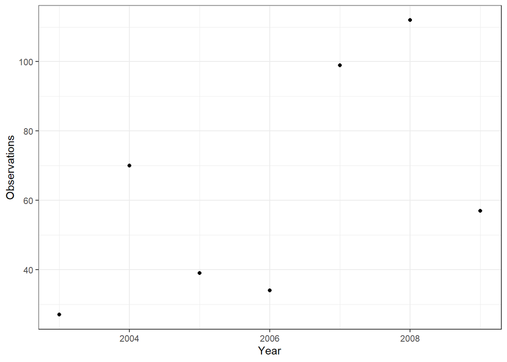

```r
# We can now create a plot of species observation per year

#install.packages(ggplot2)
library(ggplot2)

#Let's plot points for the Common Redstart
Resdstart.summary <- year.summary  %>% filter(Common.Name == "American Redstart")

ggplot(data = Resdstart.summary, aes(x = Year, y = Observations)) +
  geom_point()+
  theme_bw()
```

A tougher question: what is the average number of birds seen at a site, per day, under each of the different precipitation conditions recorded.

You can have a look at the different classes of precipitation using *unique(abmibirds$Precipitation)*

```r
precipitation.summary <- abmibirds %>% group_by(Precipitation, Year, Field.Date) %>%
  summarise(birdcounts = n()) %>%
  summarise(mean.sigthings = mean(birdcounts))
```

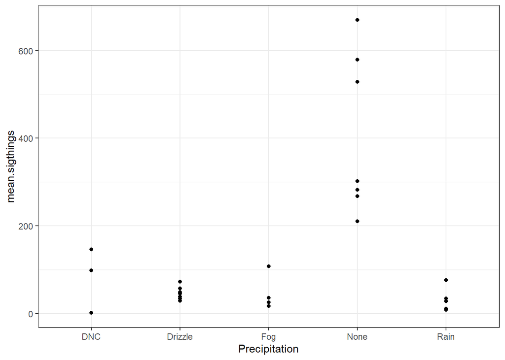

```r
#Let's plot the results
ggplot(data = precipitation.summary, aes(x = Precipitation, y =mean.sigthings)) +
  geom_point() +
  theme_bw()
```

## References / additional info

- The dplyr website: https://dplyr.tidyverse.org/index.html
- R for data science chapter 5: https://r4ds.had.co.nz/transform.html